# SNP data quality control using R

MTRabanusWallace

04/01/2017

# Introduction

We’ve now learned some R, and we have a table of SNP calls waiting to be analysed. In this session, we’ll make heavy use of `data.table` and `ggplot` to visualise and filter the dataset for analysis. We’ll also pick up some more R tricks on the way.

The most important thing to remember here is the basic rules of `data.table`, that is, the `data_table[ SELECT , DO_SOMETHING , GROUP_BY ]` syntax, summarised by this figure and on your cheat sheet.

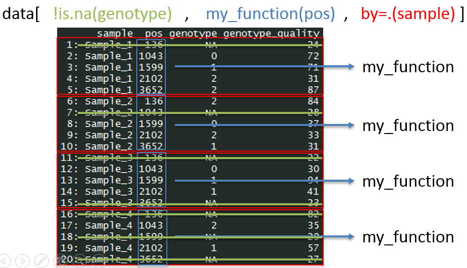

Obviously the `SELECT` field is going to be very important for selecting rows of the `data.table` that represent good (or bad) data to keep (or remove). But to work out what constitutes good/bad data, we will need to do a few basic calculations on the way. In fact, each step of filtering will involve some steps like this:

1. Calculate some indicator that tells us about the data quality
2. Visualise or summarise the data in a way that helps us to see how filtering based on the indicator would affect it
3. Filter the data
4. Re-make the visualisation to see the results

Begin by making a new script called (something like) “data_QC.R” in your scripts directory, and as you go, copy/paste or type commands into it from this document to run. By the end it will contain the whole R workflow needed to do your assignment work and produce nice figures.

Next …

# Load packages and set working directory

```r
setwd("~/workspace")
library(magrittr) #gives us access to the pipe-like `%>%` operator
library(ggplot2) #for plotting
library(data.table) #extends data.frames to data.tables
library(SNPRelate)
source("./bin/course_functions.R")
source("./bin/tim_functions.R")
```

# Read in the data and look at it

Use the fread function to access the SNP calls that we produced in the primary data session. We add an arguments here to:

1. Specify the filename of the data.
2. Tell `fread` there is no header (“first line containing column names”) in the file.
3. Tell `fread` what the column names should be.

Then we use one of my functions called `fill_missing_genotypes_with_NAs` to make sure that any missing genotypes are represented by `NA` entries in the genotype column.

Finally, we add a new column called `snp_id` using `data.table`’s modification operator `:=`. This column is **very** useful later when we work on individual SNPs. It just contains the chromosome and SNP position as a single string, separated by an underscore.

```r
#read in the file to a data.table called "vcf"
vcf <- fread( file="calls/barley_panel_snpcalls.tsv" , sep="\t" , select=c(1,2,6,8,9) , header=FALSE , col.names=c( "chr" , "pos" , "sample" , "genotype" , "genotype_quality")  )

#fill missing data with NAs. This can take a long time, be patient.
vcf <- fill_missing_genotypes_with_NAs( vcf )
#add a useful snp_id column
vcf[ , snp_id := paste0(chr,"_",pos) ,  ]

#have a look
vcf
```

As you may recall, we have:

- Columns corresponding to the classic “SNP table” entries (chromosome, pos[ition], sample, and genotype).
- The genotype quality

# Visualising the SNP data with ggplot

Recall that a ggplot command for a scatter plot looks a bit like this: `ggplot( data=DATA_TABLE , mapping=aes( x=COLUMN , y=COLUMN , colour=COLUMN , size=COLUMN ) ) + geom_point()`.

Now we choose which columns should provide the information for which feature on the graph. Since we think of a genome as a linear thing, we could begin by “laying” the SNPs along the x-axis by their positions.

```r
ggplot( data=vcf[ pos < 5000000 , , ] , mapping=aes( x=pos , y=sample ) ) + geom_point()
```

That’s better but a few things could be improved, we should limit the positions a bit more, and show the actual genotypes using colour, and also make the points a bit smaller.

```r
ggplot(   data=vcf[ pos < 500000 , , ]   ,   mapping=aes( x=pos,  y=sample ,  colour=as.factor(genotype) , alpha=genotype_quality)   ) + geom_point(size=.5)
```

That’s better. This shows the kinds of tweaking you can do to produce really informative plots for a scientific report.

# Explore your data with data.table

For the sake of memory, let’s work out some basic facts about the data. First up, how many SNP loci do we have, exactly? Here is one basic R approach, and a `data-table` approach:

```r
#using basic R
  #the `$` operator can extract the column of SNP positions ("pos") as a vector
vcf$pos
  #the `unique()` function then removes any duplicates from the vector
vcf$pos %>% unique()
  #the `length()` function returns the length of this vector
vcf$pos %>% unique() %>% length()

#using data.table
  #use the SELECT field to delete any rows where "pos" is duplicated (using the `duplicated()` logical test)
vcf[ !duplicated(pos) , , ]
  #in the DO_SOMETHING field, use the special variable `.N` (which gives you the rumber of rows).
vcf[ !duplicated(pos) , .N , ]
```

Of course, many are missing data (i.e. the genotype is “NA”). So we should count exactly how many of the data points are missing:

```r
vcf[  is.na(genotype) , .N  , ]
vcf[ !is.na(genotype) , .N  , ]
```

As you know, the great advantage of data.table comes when we want to do such a calculation for different groups of the data. Now, we use the GROUP_BY field.

```r
vcf[  is.na(genotype) , .N , by=.(sample) ] #missing
vcf[ !is.na(genotype) , .N , by=.(sample) ] #non-missing (note the `!`)
```

A final exercise to show the flexibility of `data.table`. What if we wanted to have counts of the missing and non-missing data in a single summary table? We can’t use the SELECT field any more because we need all the data avaiable in the DO_SOMETHING field. So we need another way to count NAs and non-NAs in the genotype column for each group. Remember that using `sum()` on a logical vector counts the TRUE entries (i.e., `sum(TRUE,FALSE,TRUE,TRUE)` is equal to `3` ). Using this fact:

```r
vcf[  ,                        is.na(genotype)                                               , by=.(sample) ] #produces a logical vector telling us whether the genotype is NA
vcf[  ,                    sum(is.na(genotype))                                              , by=.(sample) ] #gives the number of "TRUE"s in the vector
vcf[  , .(   number_of_NAs=sum(is.na(genotype))  )                                           , by=.(sample) ] #DO_SOMETHING now produces a list with `.()`, which allows us to name the output
vcf[  , .(   number_of_NAs=sum(is.na(genotype))  ,  number_of_nonNAs=sum(!is.na(genotype))  ), by=.(sample) ] #produce TWO columns of output just like we wanted
```

# Filtering

The fact that most genotype calls are actually missing tells you that these genotypes are mostly low quality! Filtering SNP datasets is both art and science. We will use our R skills to remove bad genotypes, then remove bad SNP loci, and maybe even to remove whole samples that seem universally unreliable.

## Filtering individual genotypes

Each genotype has a quality score associated with it, and we’ll remove those with particularly low qualities. But how do we know what counts as “low”? Remember my “plot density” function `pd()`.

```r
vcf$genotype_quality %>% pd()

#try adjusting bw=
vcf$genotype_quality %>% pd( bw=.5 )
```

With the trial data I used, I got output like this:

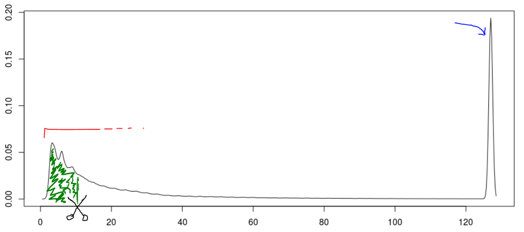

So we have a “peak” of high genotype quality scores (blue). These reflect a large number of samples achieving some arbitrary “maximum” quality score set by the calling program (bcftools in this case). Then we have a lot of low-quality calls (red), with more calls at the very lowest qualities.

Choosing what cutoff to use is always a trade-off. On one hand, we want the best quality data available, on the other hand, we want a high number of useful SNPs.

We can decide to try a cutoff point for quality now. You will decide upon, test, and justify your own cutoffs, but for now let’s choose 10 (scissors), which would cut off all the SNPs with qualities < 10 (green).

Why not just go for the really high qualities? Well, one reason is that we will filter so many ways that keeping as much data as possible in this step is useful. Also, heterozygote calls often get given low qualities, partly because it’s harder to distinguish heterozygotes from sequencing errors or artefacts of bad mapping (especially at low read depths). So it’s worth keeping some low-quality data so that we don’t bias too much against SNP loci with a lot of heterozygous calls.

These are PHRED-scaled quality scores. Recall from the lecture: $\text{PHRED score} = -10 * \log_{10}( \text{probability of error} )$. So even if we allow through calls with a score as low as 10, we only expect to tolerate errors about 10% of the time in those few calls.

To filter the low-quality genotypes, we can just SELECT the genotypes with low qualities, and convert them into “NA”, using `data.table`’s modification operator `:=` in the DO_SOMETHING field.

```r
#set the minimum quality
minimum_genotype_quality <- 10 #try different numbers here, and justify your choice using plots in the assignment.
#how many SNPs would this leave?
vcf[ genotype_quality < minimum_genotype_quality , length(unique(snp_id)) ]

#filter
vcf[ genotype_quality < minimum_genotype_quality  ,  genotype := NA  ,  ]
#have a look at the genotypes again with the filter applied
ggplot(   data=vcf[ pos < 500000]   ,   mapping=aes( x=pos,  y=sample ,  colour=as.factor(genotype) , alpha=genotype_quality)   ) + geom_point(size=.5)
```

## Filtering SNP loci

Before we just removed individual genotype calls, but now we will remove whole SNP loci (i.e., whole “columns” of SNPs as you see them in the plots). Many (most!) SNP loci are not very useful because they only have genotype data for a few samples. We need a count of missing genotypes for each SNP locus so we can remove the ones with too much missing data.

```r
#add count of called snps per snp locus
vcf[ , n_NAs_snp := sum(is.na(genotype)) , by=.(snp_id) ]

#convert this to a percentage in a new column called pct_calls_snp
vcf[ , percent_NAs_snp := (n_NAs_snp/.N)*100 , by=.(snp_id) ]
```

Again, we need to see our data to make a good decision:

```r
#add count of called snps per snp locus
vcf$percent_NAs_snp %>% pd
```

Here’s what I got:

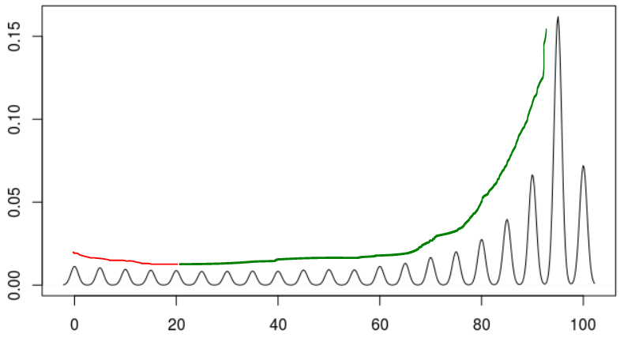

As we can see, most of these SNP loci have above 20% missing genotypes (green line), and it’s actually a minority of SNPs with almost complete data (red line).

```r
#set the minimum
max_percent_missing <- 10 #try different numbers here, und justify your choice using plots in the assignment.
#how many SNPs would this leave?
vcf[ percent_NAs_snp < max_percent_missing , length(unique(snp_id)) ]

#over-write the table 'vcf' with a filtered table that includes only the SNPs where percent_NAs_snp is less than max_percent_missing
vcf <- vcf[ percent_NAs_snp < max_percent_missing , ,  ]

#produce the same plot as before showing the SNPs after filtering
#have a look at the genotypes again with the filter applied
ggplot(   data=vcf[ pos < 500000 , , ]   ,   mapping=aes( x=pos,  y=sample ,  colour=as.factor(genotype) , alpha=genotype_quality)   ) + geom_point(size=.5)
```

Already the SNPs look much cleaner, and as you can see, it’s normal to throw away most of the data and just keep the very best.

## Filtering by minor allele frequency

To filter out alleles that only occur in a small number of samples, we need to calculate the Minor Allele Frequency at each SNP locus, that is, the percentage of whatever allele is the least common.

Obviously if we have changed all the genotype calls at a locus to NA, then we can’t calculate a MAF. Also, if all the remaining genotypes are the same then there is only one allele. Here’s an example from my genotype visualisation:

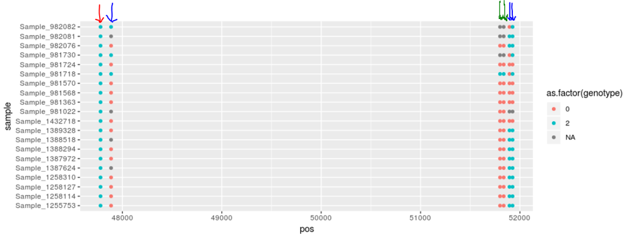

Here, the red arrow marks one of these *monomorphic* loci, where all the genotypes are the same and hence not informative. The loci marked green have just one instance of the minor allele, which means it can’t tell us anything about inter-sample relationships and very little about association. So we should delete it. The SNP loci marked blue look quite good to me.

Run the following lines calculate the MAF for each SNP locus in a column called “MAF_snp”

```r
#calculate the number of calls of each type for each locus
vcf[ ,     n_genotype_2_snp    := sum( genotype==2 , na.rm=TRUE )    ,    by=.(snp_id) ]
vcf[ ,     n_heterozygote_snp  := sum( genotype==1 , na.rm=TRUE )    ,    by=.(snp_id) ]
vcf[ ,     n_genotype_0_snp    := sum( genotype==0 , na.rm=TRUE )    ,    by=.(snp_id) ]
#calculate the allele frequencies for each allele
vcf[  ,  AF_2_snp := ((2*n_genotype_2_snp) + n_heterozygote_snp)/(2*.N) ,  by=.(snp_id) ]
vcf[  ,  AF_0_snp := ((2*n_genotype_0_snp) + n_heterozygote_snp)/(2*.N) ,  by=.(snp_id) ]
#calculate the minor allele frequency
vcf[  ,  MAF_snp  := min( AF_2_snp , AF_0_snp ) , by=.(snp_id) ]
```

So, what’s spread of values?

```r
vcf$MAF_snp %>% pd(bw=.01)
```

Resulting in something like this:

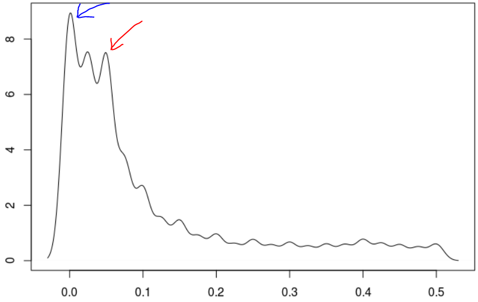

```r
#set minimum
min_MAF_snp <- .05 #try different numbers here, und justify your choice using plots in the assignment.
#how many SNPs would this leave?
vcf[ MAF_snp > min_MAF_snp , length(unique(snp_id)) ]

#filter
vcf <- vcf[ MAF_snp > min_MAF_snp ,  , ]
#have a look (you may have to alter the "pos" range here since many SNP loci are now gone)
ggplot(   data=vcf[ pos < 500000 , , ]   ,   mapping=aes( x=pos,  y=sample ,  colour=as.factor(genotype) )   ) + geom_point(size=.5)
```

## Filtering by heterozygosity

Samples or SNPs with excess heterozygosity are suspicious. A SNP with excess heterozygosity could be the result of reads from different paralogous regions of the genome mapping to one place in the reference. Here are some examples I found in my data (red arrows).

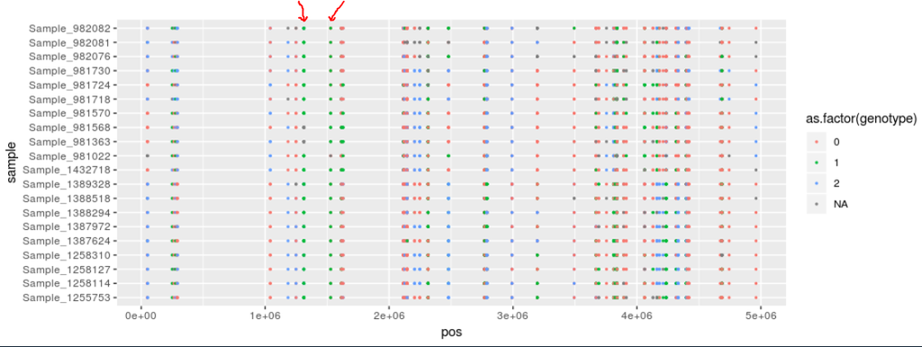

To work out how much heterozygosity is “normal” we could base it on some assumption. In some cases we assume the population is close to a state called Hardy-Weinberg Equilibrium, meaning that individuals have been randomly mating for at least one generation, with no selection or mutation or migration. This is certainly not the case for our samples (in fact, it basically never happens in any natural population).

Furthermore, we can’t be sure we even measured the heterozygosity accurately enough to begin with since 1) not all heterozygotes are detected by the calling process, and 2) they may have been preferentially filtered in previous steps. And both these problems are exacerbated by low read depths.

So, an “assumption-free” approach to heterozygote filtering might be wise. We will just look at the distribution of heterozygote frequencies and remove extremely high values.

```r
#calculate the percentage of heterozygote calls at each SNP locus
vcf[  ,  percent_heterozygous_snp := n_heterozygote_snp/.N , by=.(snp_id) ]

#plot the spread
vcf$percent_heterozygous_snp %>% pd()
```

I got this:

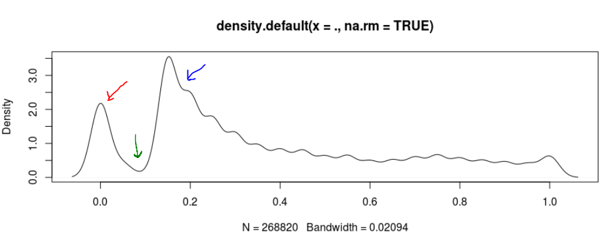

It looks like some of the heterozygous calls in low-heterozygosity samples might have been removed by filtering (green arrow), leading to an excessive number of zero-heterozygosity samples (red arrow). But most samples clearly fall around the 20% heterozygous range, so I have chosen to remove everything above 40% to be safe.

```r
max_percent_heterozygous <- 0.4
#how many SNPs would this leave?
vcf[ percent_heterozygous_snp < max_percent_heterozygous , length(unique(snp_id)) ]


vcf <- vcf[ percent_heterozygous_snp < max_percent_heterozygous , , ]
```

# Imputation of missing data

Thanks to Linkage Disequilibrium, missing genotype calls can be guessed based on genetically-linked loci. Some very sophisticated methods exist for this, but we will use a simple method called K-nearest-neighbours that runs very quickly, (although the accuracy is still comparatively good).

Run the functions below to first test the imputation accuracy, then get back your data with an added “imputed genotype” column. The accuracy may depend on both the filtering steps so far, and the parameter $k$ of the imputation algorithm, so you may wish to experiment with a few values (between 3 and 10, say) to see if you can increase the accuracy.

This will take a long time if you have more than about 5,000 SNP loci, so if it sticks for too long, try adjusting your filters to exclude more loci.

```r
k <- 3  #try different numbers here, und justify your choice using the outcome of the `test_imputation()` function test in the assignment
test_imputation( data=vcf , k=k ) #can take a long time, have a coffee break

#impute genoptypes in a new column called "imputed_genotype"
vcf <- impute_genotypes_using_K_nearest_neighbour_method( data=vcf , k )
#replace missing genotype calls with their imputed calls
vcf[ is.na(genotype) , genotype := imputed_genotype , ]
```

# Showing Linkage Disequilibrium (LD)

LD leads to groups of neighbouring SNPs with identical or almost identical genotypes. There’s not much advantage to be gained looking for trait associations with every single one of these linked SNPs: they’ll show the same amount of associaton anyway. But they will increase the p-value cutoff we choose when we assess the GWAS results, and they will make the GWAS analysis MUCH slower. So it’s common to reduce linked SNP loci to a smaller number of representative loci.

This is a complex analysis, and you don’t need to understand every part of the code; just change the numbers that control the filtering.

The code below calls a package called *SNPRelate*, which quantifies LD by taking the correlation coefficient $r^{2}$ between each pairs of SNPs. It also suggests which loci should be filtered if they are highly correlated with loci nearby. The parameters `max_corr` and `window_size` below define what qualifies as “highly correlated”, and what qualifies as “nearby”. For example, if you give max_corr the value 0.5, and window_size the value 2,500,000, then SNPRelate will give back a set of SNPs where *no two SNP loci within 2,500,000 base pairs of each other will ahve a correlation coefficient above 0.5*.

To help us choose sensible parameters, the block below will produce two heatmaps: First, a heatmap showing the all the correlations that reach the chosen threshold (`max_corr`) in red and the others in blue. Second, the same heatmap showing only the SNPs that would survive the filtering process. Try to reduce the number of SNPs to below 5,000.

```r
#set a SNP-wise correlation limit for filtering by LD
max_corr <- 0.5  #try different numbers here, und justify your choice using plots in the assignment.
window_size <- 2500000 #try different numbers here, und justify your choice using plots in the assignment.

#run the LD analysis with these three lines
LD_analysis <- generate_LD_matrix( data=vcf , ld.threshold=max_corr , slide.max.bp=window_size )
LD_dt <- LD_analysis$LD_data
SNPs_pass_filter <- LD_analysis$good_SNPs$chrchr1H

#here we have a list of SNPs that passed the filtering
SNPs_pass_filter

#visualise the results with these commands.
  #... with the axes as the SNP positions
LD_heatmap_pos( data=LD_dt[pos1<10000000 & pos2<10000000 , , ] , midpoint=max_corr )
  #... or with the SNPs just lined up in order along the axes
LD_heatmap_order( data=LD_dt[pos1<10000000 & pos2<10000000 , , ] , midpoint=max_corr )
#count the SNP loci that would be left over
SNPs_pass_filter %>% length
#visualise how the results would look after filtering
LD_heatmap_order( data=LD_dt[pos1<10000000 & pos2<10000000 , , ][snp_id1 %in% SNPs_pass_filter & snp_id2 %in% SNPs_pass_filter ] , midpoint = max_corr )
```

If you’ve done it correctly, your first plot with `LD_heatmap_order()` will show LD between close SNPs as is normal (the red diagonal), and the second will show you the LD after choosing a set of unlinked SNPs.

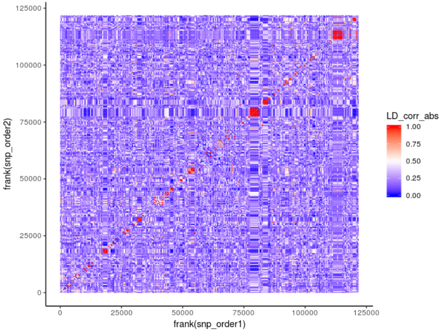

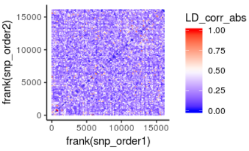

The line `SNPs_pass_filter %>% length` tells you how many SNPs will be in your final data set.

This is the final filtering step, so you want to check here that you have enough data to work with, but not too much—which would really slow down later steps (3000–5000 final SNPs is a good range). You may need to repeat the whole SNP filtering process a few times and change the filtering criteria at earlier steps to check the results. Once you get to this stage and are happy with your filtering settings, then perform the final filtering of linked SNPs like this:

```r
#here, we use the %in% operator. This selects ONLY rows where the snp_id is in the list SNPs_pass_filter
vcf <- vcf[ snp_id %in% SNPs_pass_filter , , ]
```

Congratulations, you’ve created your curated genotype dataset! Save it in R’s special “.Rds” format so we can access it later for the analysis.

```r
saveRDS(vcf,"calls/barley_panel_snpcalls_filtered.Rds")
```

# Exercises:

```r
vcf[ , expected_het_count := ( 2 * minor_allele_frequency * (1-minor_allele_frequency) ) * ncalls_snp , by=.(snp_id) ]
vcf[ , observed_het_count := sum( genotype==1 , na.rm=TRUE ) , by=.(snp_id) ]
vcf[ , HWE_F := 1 - ( observed_het_count / expected_het_count ) ]
```